# Pan-cancer cluster-of-clusters analysis - code

Jackie Rao

2024-11-19

# 1 Load data

```r
#install.packages("synapser", repos = c("http://ran.synapse.org", "https://cloud.r-project.org")) #need to add the Sage Bionetworks R Archive Network (RAN) to the repository list. Synapser depends on a Python installation: see https://r-docs.synapse.org/articles/installation.html for more information on installing this package

library(synapser)
synLogin(silent = TRUE) #Login to Synapse: see https://r-docs.synapse.org/articles/manageSynapseCredentials.html for examples of managing credentials
```

## 1.1 DNA methylation data

```r
dnameth_file <- synGet("syn1875816", downloadLocation = "~/pancan_data")
methylationclustA <- read.csv('~/pancan_data/DNA_Methylation_Cluster_130519.csv', row.names = 1)
methylationclust <- methylationclustA[!is.na(methylationclustA$Cluster),]
rownames(methylationclust) <- NULL

methylationclust$TCGA.ID <- substr(methylationclust$TCGA.ID,1,15)
methduplicates <- which(duplicated(methylationclust$TCGA.ID))

for (d in methduplicates){
  otherdups <- which(methylationclust[,1] == methylationclust[d, 1])
  for (i in 1:length(otherdups)) {
    if (methylationclust[d, 2] != methylationclust[otherdups[i], 2]){
      print(d)
      print(otherdups[i])
      print(methylationclust[d, 2])
      print(methylationclust[otherdups[i], 2])
    }
  }
}
#Disrepency - 2061 and 2060 have the same TCGA ID but different clusters when 12


methylationclustA %>%
  filter(str_detect(TCGA.ID, "TCGA-BH-A1FE"))
```

```
##                        TCGA.ID Cluster
## 1 TCGA-BH-A1FE-01A-11D-A13K-05       9
## 2 TCGA-BH-A1FE-06A-11D-A212-05       2
## 3 TCGA-BH-A1FE-11B-14D-A13T-05      NA
```

```r
#TCGA-BH-A1FE-01A-11D-A13K-05 in Cluster 9, TCGA-BH-A1FE-06A-11D-A212-05 in Cluster 2, TCGA-BH-A1FE-11B-14D-A13T-05 is NA

#methduplicates <- append(methduplicates, 2060)
methylationclust <- methylationclust[-methduplicates,]
colnames(methylationclust)[1] <- "ID"
```

## 1.2 mRNA seq data

```r
mrna_file <- synGet("syn1715788", downloadLocation = "~/pancan_data")
mrnaclustA <- read.csv('~/pancan_data/PanCan12.3602-corrected-v3.Subtypes.K16.txt', sep = "\t")
mrnaclust <- mrnaclustA[,c('Sample', 'K16')]
mrnaclust$Sample <- substr(mrnaclust$Sample,1,15)
mrnaduplicates <- which(duplicated(mrnaclust$Sample)) #Duplicates

for (d in mrnaduplicates){
  otherdups <- which(mrnaclust[,1] == mrnaclust[d, 1])
  for (i in 1:length(otherdups)) {
    if (mrnaclust[d, 2] != mrnaclust[otherdups[i], 2]){
      print(d)
      print(otherdups[i])
      print(mrnaclust[d, 2])
      print(mrnaclust[otherdups[i], 2])
    }
  }
}
#Disrepancy in 656, 657
mrnaclustA %>%
  filter(str_detect(Sample, "TCGA-BH-A1FE"))
```

```
##                         Sample Tissue.Type K16
## 1 TCGA-BH-A1FE-01A-11R-A13Q-07        BRCA   7
## 2 TCGA-BH-A1FE-06A-11R-A213-07        BRCA   6
```

```r
#TCGA-BH-A1FE-01A-11R-A13Q-07, TCGA-BH-A1FE-06A-11R-A213-07 same duplicate as in DNA methylation

#methduplicates <- append(methduplicates, 656)
mrnaclust <- mrnaclust[-mrnaduplicates,]
colnames(mrnaclust)[1] <- "ID"
```

## 1.3 miRNA seq data

```r
mirna_file <- synGet("syn2027079", downloadLocation = "~/pancan_data")
mirnaclustA <- read.csv('~/pancan_data/miRNA.k15.txt', sep = "\t")
mirnaclust <- as.data.frame(cbind(Sample = mirnaclustA$Sample, Cluster = mirnaclustA$Cluster, Disease_code = mirnaclustA$Disease_code))
mirnaclust$Sample <- substr(mirnaclust$Sample,1,15)
mirnaduplicates <- which(duplicated(mirnaclust$Sample)) #Duplicates

for (d in mirnaduplicates){
  otherdups <- which(mirnaclust[,1] == mirnaclust[d, 1])
  for (i in 1:length(otherdups)) {
    if (mirnaclust[d, 2] != mirnaclust[otherdups[i], 2]){
      print(d)
      print(otherdups[i])
      print(mirnaclust[d, 2])
      print(mirnaclust[otherdups[i], 2])
    }
  }
}
```

```
## [1] 1726
## [1] 1101
## [1] "14"
## [1] "13"
## [1] 2224
## [1] 1340
## [1] "5"
## [1] "14"
## [1] 3079
## [1] 1422
## [1] "7"
## [1] "14"
## [1] 3251
## [1] 1321
## [1] "9"
## [1] "13"
## [1] 3617
## [1] 1842
## [1] "4"
## [1] "10"
## [1] 3957
## [1] 3296
## [1] "4"
## [1] "9"
## [1] 3958
## [1] 2980
## [1] "4"
## [1] "7"
```

```r
#List of duplicates
#1726, 1101
#2224, 1340
#3079, 1422
#3251, 1321
#3617, 1842
#3957, 3296
#3958, 2980

mirnaclustA[c(1726, 1101),]
```

```
##      Cluster Disease_code               Sample               X Cluster.1
## 1726      14         KIRC TCGA-AK-3443-01A-01T TCGA-AK-3443-01        14
## 1101      13         KIRC TCGA-AK-3443-01A-02R TCGA-AK-3443-01        13
```

```r
mirnaclustA[c(2224, 1340),]
```

```
##      Cluster Disease_code               Sample               X Cluster.1
## 2224       5         KIRC TCGA-A3-3308-01A-02R TCGA-A3-3308-01         5
## 1340      14         KIRC TCGA-A3-3308-01A-01T TCGA-A3-3308-01        14
```

```r
mirnaclustA[c(3079, 1422),]
```

```
##      Cluster Disease_code               Sample               X Cluster.1
## 3079       7         BRCA TCGA-A7-A13G-01A-11R TCGA-A7-A13G-01         7
## 1422      14         BRCA TCGA-A7-A13G-01B-04R TCGA-A7-A13G-01        14
```

```r
mirnaclustA[c(3251, 1321),]
```

```
##      Cluster Disease_code               Sample               X Cluster.1
## 3251       9         BRCA TCGA-AC-A2QH-01A-11R TCGA-AC-A2QH-01         9
## 1321      13         BRCA TCGA-AC-A2QH-01B-04R TCGA-AC-A2QH-01        13
```

```r
mirnaclustA[c(3617, 1842),]
```

```
##      Cluster Disease_code               Sample               X Cluster.1
## 3617       4         BRCA TCGA-AC-A3QQ-01A-11R TCGA-AC-A3QQ-01         4
## 1842      10         BRCA TCGA-AC-A3QQ-01B-06R TCGA-AC-A3QQ-01        10
```

```r
mirnaclustA[c(3957, 3296),]
```

```
##      Cluster Disease_code               Sample               X Cluster.1
## 3957       4         BRCA TCGA-A7-A26I-01B-06R TCGA-A7-A26I-01         4
## 3296       9         BRCA TCGA-A7-A26I-01A-11R TCGA-A7-A26I-01         9
```

```r
mirnaclustA[c(3958, 2980),]
```

```
##      Cluster Disease_code               Sample               X Cluster.1
## 3958       4         BRCA TCGA-A7-A26F-01B-04R TCGA-A7-A26F-01         4
## 2980       7         BRCA TCGA-A7-A26F-01A-21R TCGA-A7-A26F-01         7
```

```r
#Remove all of these for avoidance of doubt

mirnaduplicates <- append(mirnaduplicates, c(1101, 1340, 1422, 1321, 1842, 3296, 2980))
mirnaclust <- mirnaclust[-mirnaduplicates,]
colnames(mirnaclust) <- c("ID", "miRNA", "Disease_code")
```

## 1.4 RPPA data

```r
rppa_file <- synGet("syn1756922", downloadLocation = "~/pancan_data")
rppaclust <- read.csv('~/pancan_data/PanCan11_RBN_SimpleCluster_20130411.csv')
rppaclust$ID <- gsub(".", "-", rppaclust$ID, fixed = TRUE)
which(duplicated(rppaclust$ID)) #No duplicates
```

```
## integer(0)
```

## 1.5 SCNA data

```r
scna_file <- synGet("syn1712142", downloadLocation = "~/pancan_data")
scnaclust <- read.csv('~/pancan_data/SCNA_Cluster_table.txt', sep = "\t")
scnaclust$ID <- substr(scnaclust$sample,1,15)
which(duplicated(scnaclust$ID)) #No duplicates
```

```
## integer(0)
```

# 2 Format data

Create a Cluster of Clusters from Hoadley et al.’s cluster subtype assignments.

```r
#We only want to keep the samples used in the original COCA analysis
coca_file <- synGet("syn1889916", downloadLocation = "~/pancan_data") #Download Hoadley et al.'s subtype assignments

cocaog <- read.csv('~/pancan_data/CofC.noMut.K13.Hoadley.20130523.txt', sep = '\t') #This dataframe has Hoadley et al.'s assignments
cocaog$Samples <- substr(cocaog$Samples,1,15)
samples <- as.data.frame(cocaog$Samples)
colnames(samples) <- 'ID'
which(duplicated(samples)) #No duplicates
```

```
## integer(0)
```

```r
samples12 <- samples
samples12$ID <- substr(samples$ID,1,12)

clusterdf12 <- left_join(samples12, rppaclust) #Joins the clusters from RPPA to samples via a left_join in tidyverse
clusterdf <- as.data.frame(cbind(samples$ID, clusterdf12[,2])) #Change the names to 15 characters
colnames(clusterdf) <- c("ID", "RPPA")

#Put all subtype assignments into one dataframe

clusterdf <- clusterdf %>% left_join(scnaclust[,c("ID", "k8")]) %>%
  left_join(methylationclust) %>% left_join(mrnaclust) %>% left_join(mirnaclust[,c("ID", "miRNA")])
colnames(clusterdf) <- c("ID", "RPPA", "SCNA", "DNA_meth", "mRNA", "miRNA")

#Create Matrix of Clusters from this

N <- dim(clusterdf)[1] #Number of observations
M <- dim(clusterdf)[2]-1 #Number of datasets

# Number of clusters in each dataset
K <- rep(0, M)
for (i in 1:M) {
  K[i] <- length(unique(na.omit(clusterdf[,i + 1])))
}

#Create matrix
moc <- matrix(0, N, sum(K))
rownames(moc) <- clusterdf$ID
colnames(moc) <- rep(0, sum(K))

#moc[n, j] should be 1 if n is in cluster

count = 0
for (i in 1:length(K)){
  for (ki in 1:K[i]){
    colnames(moc)[count + ki] <- paste0(colnames(clusterdf)[i+1], "_", unique(na.omit(clusterdf[,i+1]))[ki])
  }
  count <- count + K[i]
  print(count)
}
```

```
## [1] 8
## [1] 16
## [1] 35
## [1] 51
## [1] 66
```

```r
count = 0
for (i in 1:length(K)){
  for (ki in 1:K[i]){
    #Fill in column by column
    moc[,count + ki] <- clusterdf[,i + 1] == unique(na.omit(clusterdf[,i+1]))[ki]
  }
  count <- count + K[i] #cumulative counting
  #print(count)
}

#'moc' is our Matrix of Clusters for clustering in COCA
moc[is.na(moc)] <- 0 #Missing cluster assignements currently NA - make these 0 for analysis
```

# 3 Run VICatMix

Perform the clustering, with 25 initialisations and 15 maximum clusters. Complete linkage and a 0.95 threshold for variable selection is used for the summarisation by default. The maximum number of clusters can be changed for coarser/broader clustering structures (eg. 40, as in the Supplementary Material).

Uncomment the below lines to run the computation - these have been commented out so the Rmd file runs quickly.

```r
#set.seed(205)
#library(VICatMix)

#library(foreach)
#library(doParallel)
#library(doRNG)
#registerDoParallel(25)

#moc[is.na(moc)] <- 0
#cocaclust_avg <- runVICatMixAvg(moc, 15, 0.01, inits = 25, parallel = TRUE)
```

# 4 Plots

Load data for plotting - this is the output from the above computation.

```r
#Comment out the following line if VICatMix has been run by the user
load("cocaclust_avg.RData")
```

## 4.1 Heatmaps

Create heatmaps with the ‘pheatmap’ package.

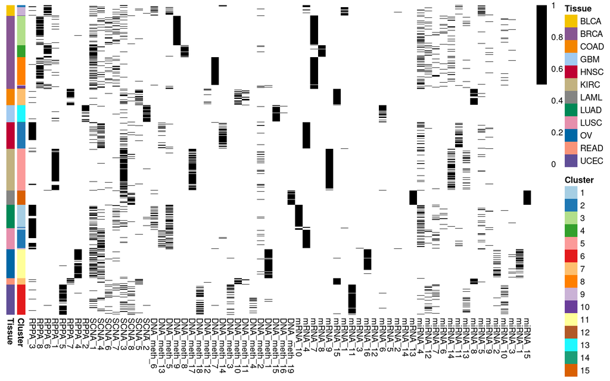

```r
#Create heatmap depicting the Matrix of Clusters, cluster subtype assignements by VICatMix, and tissue of origin (Figure 7)

cocaav15 <- cocaclust_avg$labels_avg

currentAnnotationRow <- data.frame(
  Cluster = factor(cocaav15),
  Tissue = factor(cocaog$Tissue) #This dataset was loaded in earlier - consists of tissues of origin and Hoadley et al.'s subtype assignements
)

annotationColor <- list(Tissue  = c("BLCA" = "#f3c300", "BRCA" = "#875692", "COAD" = "#f38400", "GBM" = "#a1caf1", "HNSC" = "#be0032", "KIRC" = "#c2b280",
                                    "LAML" = "#848482", "LUAD" = "#008856", "LUSC" = "#e68fac", "OV" = "#0067a5", "READ" = "#f99379", "UCEC" = "#604e97"),
                        Cluster = c("1" = "#A6CEE3", "2" = "#1F78B4", "3" = "#B2DF8A", "4" = "#33A02C", "5" = "#FB9A99", "6" = "#E31A1C", "7" = "#FDBF6F",
                                    "8" = "#FF7F00", "9" = "#CAB2D6", "10" = "#6A3D9A", "11" = "#FFFF99", "12" = "#B15928", "13" = "#1ff8ff", "14" = "#1B9E77", "15" = "#D95F02")
)

rownames(currentAnnotationRow) <- rownames(moc)

pheatmap(moc[order(cocaog$Tissue, cocaav15),],
         show_rownames = F, annotation_row = currentAnnotationRow,
         annotation_colors= annotationColor,
         color = colorRampPalette(colors = c("white", "black"))(2),
         cluster_rows = F, cluster_cols = F, fontsize = 8)
```

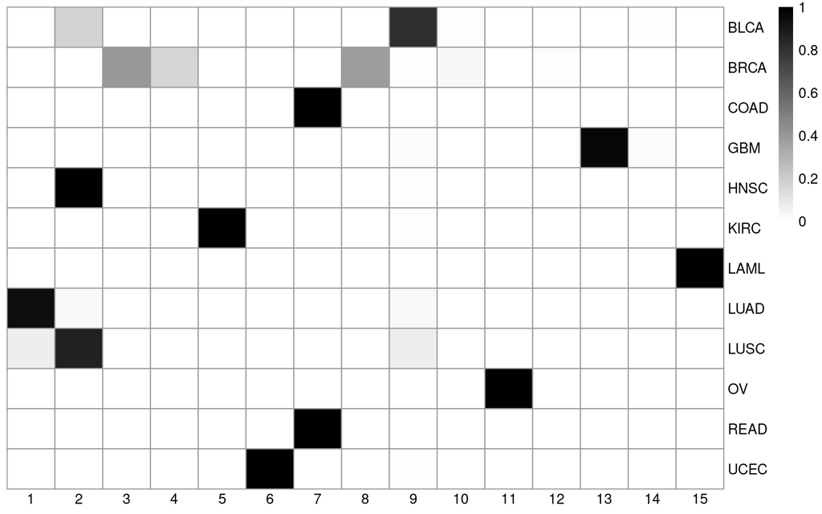

```r
#Heatmap showing the correspondence between clusters produced by VICatMix-Avg and the tissues of origin (Figure 6)

COCAPercentHeat15 <- matrix(0, nrow = 12, ncol = 15)
tissuesandclusters <- as.data.frame(cbind(cocaog$Tissue, cocaav15))

tissues <- levels(factor(cocaog$Tissue))

for (i in 1:12){
  for (j in 1:15){
    COCAPercentHeat15[i, j] <- sum(tissuesandclusters$V1 == tissues[i] & tissuesandclusters$cocaav15 == j) / sum(cocaog$Tissue == tissues[i])
  }
}

rownames(COCAPercentHeat15) <- levels(factor(cocaog$Tissue))
colnames(COCAPercentHeat15) <- paste0(seq(ncol(COCAPercentHeat15)))

pheatmap(COCAPercentHeat15, display_numbers = F,
         cluster_rows = F, cluster_cols = F, fontsize_number = 10,
         color = colorRampPalette(colors = c("white", "black"))(198),
         show_rownames = T, show_colnames = T, angle_col = 0)
```

## 4.2 BRCA comparison

Use PAM50 subtype assignments from Berger et al. (2018) (Supplementary Table S4) to compare our cluster assignments from VICatMix-Avg to PAM50 subtypes. This data is used under the terms of the Creative Commons Attribution-NonCommercial-NoDerivatives 4.0 International License (CC BY-NC-ND 4.0). (https://creativecommons.org/licenses/by-nc-nd/4.0/)

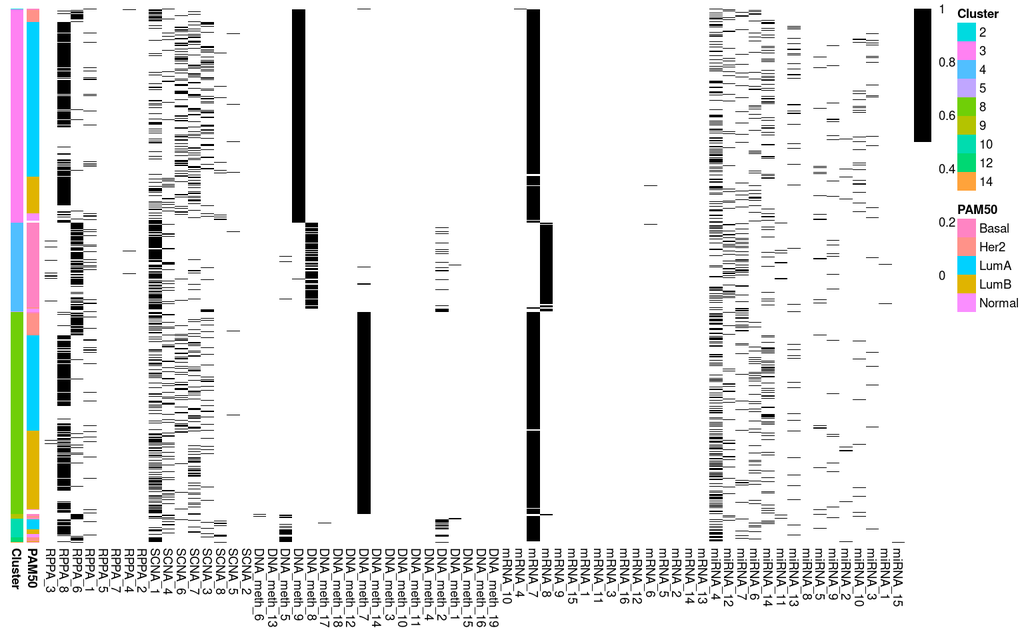

```r
COCAbestlabelsdf15 <- as.data.frame(cbind(cocaog, cocaav15)) #Combine tissue type and cluster assignment to one data frame
PAM50 <- read.csv("TCGAPAM50_2018.csv", header = TRUE) #Load in PAM50 subtypes
PAM50 <- PAM50 %>% select(Sample.ID, BRCA_Subtype_PAM50)
BRCAcoca15 <- COCAbestlabelsdf15 %>% filter(Tissue == "BRCA")
BRCAcoca15 <- BRCAcoca15 %>%
  mutate(Sample.ID = str_extract(Samples, "^.{1,12}"))

BRCAcoca15 <- left_join(BRCAcoca15, PAM50, by = "Sample.ID")

BRCAlist <- which(cocaog$Tissue == "BRCA") #Find which row numbers are BRCA samples

BRCAmoc <- moc[BRCAlist,]

currentAnnotationRow <- data.frame(
  PAM50 = factor(BRCAcoca15$BRCA_Subtype_PAM50),
  Cluster = factor(BRCAcoca15$cocaav15)
)
rownames(currentAnnotationRow) <- rownames(BRCAmoc)

pheatmap(BRCAmoc[order(BRCAcoca15$cocaav15, BRCAcoca15$BRCA_Subtype_PAM50),], fontsize = 7,
         show_rownames = F, annotation_row = currentAnnotationRow,
         #annotation_colors= annotationColor,
         color = colorRampPalette(colors = c("white", "black"))(2),
         cluster_rows = F, cluster_cols = F, name = "score")
```

```r
freqtableBRCA <- BRCAcoca15 %>%
  count(BRCA_Subtype_PAM50, cocaav15) %>%
  pivot_wider(names_from = cocaav15, values_from = n, values_fill = list(n = 0), names_sort = TRUE)
#Gives us the number of BRCA samples in each cluster for each PAM50 subtype
print(freqtableBRCA)
```

```
## # A tibble: 6 × 10
##   BRCA_Subtype_PAM50   `2`   `3`   `4`   `5`   `8`   `9`  `10`  `12`  `14`
##   <chr>              <int> <int> <int> <int> <int> <int> <int> <int> <int>
## 1 Basal                  1     1   132     0     3     3     0     0     1
## 2 Her2                   0    19     2     0    34     3     1     7     0
## 3 LumA                   0   241     0     0   149     0    16     0     0
## 4 LumB                   0    57     0     0   123     0     7     1     0
## 5 Normal                 0    12     4     1     1     1     5     0     0
## 6 <NA>                   0     3     0     0     6     0     0     0     0
```